# CART Lab

**Directions**:

- Please begin by stepping through the “CART functions” section on your own before moving on to the main and challenge tasks
- I would like you to work with a partner on the main and challenge tasks, my hope is to have a couple of pairs share their answers/findings with the class

$~$

### CART functions

The functions used to fit and visualize CART models belong to the following packages:

```r
library(rpart)
library(rpart.plot)
```

The `rpart` function will fit a CART model using the same formula notation as functions like `lm` and `glm`:

```r
data("iris")  ## Loads the iris data
myTree <- rpart(Species ~ Sepal.Length + Sepal.Width, data = iris)
```

The `rpart.plot` function creates nice visualizations of fitted CART models:

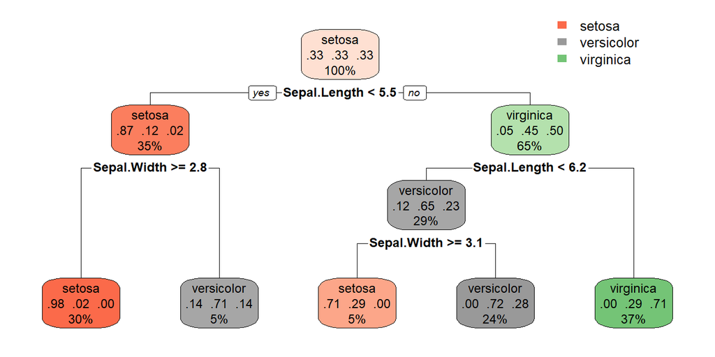

```r
rpart.plot(myTree, extra=104) ## "extra = 104" adds info to the tree
```

Stopping criteria can be modified using the `control` argument, the proper syntax is demonstrated below:

```r
biggerTree <- rpart(Species ~ Sepal.Length + Sepal.Width, data = iris,
                     control = rpart.control(cp = 0.008, minsplit = 6))
```

Splitting criteria can be modified using the `parms` argument, the proper syntax is demonstrated below:

```r
infoTree = rpart(Species ~ Sepal.Length + Sepal.Width, data = iris,
                  parms = list(split = "information"))

giniTree = rpart(Species ~ Sepal.Length + Sepal.Width, data = iris,
                  parms = list(split = "gini"))
```

$~$

### Data Dictionary

In the early 2000s, a research team comprised of US and Bangladesh scientists measured the arsenic levels of wells in Arahazar upazila, Bangladesh. The team identified safe and unsafe wells (arsenic concentrations $\geq 0.5 \mu g/L$), and they distributed materials encouraging residents who used unsafe wells to switch to safe ones. A few years later, researchers followed up to see which of these residents had actually switched to safer wells.

```r
wells = read.csv("https://remiller1450.github.io/data/Wells.csv")
```

The data contains following variables:

- **switch** - Whether or not the household switched to a safe well
- **arsenic** - The arsenic level of the household’s original well (note that all are at least 0.5, the threshold for a well being considered unsafe)
- **distance** - How many meters the household would need to travel to get to the nearest safe well
- **education** - How many years of education attained by the head of the household
- **association** - A binary variable describing whether or not any members of the household participated in any community organizations

$~$

### Main Task

**Question #1**: The three components of this question focus on the basics of fitting, visualizing, and understanding a CART model.

- **Part A**: Fit a CART model (using default options) to the `wells` data that predicts whether a family switches as a function of the variables “arsenic”, “distance”, “education”, and “association”. Then, use the `rpart.plot` function with the argument `extra = 104` to visualize the fitted model.
- **Part B**: Consider the bottom left-most terminal node of the tree. In terms of the observed variables, what must be true of all the observed families that are represented by this node?
- **Part C**: The 100th family in the dataset was using a well with an arsenic concentration of 1.93, was located 20.23 meters from the nearest safe well, had no associations within the community, and was led by a head of household with zero years of formal education. Which terminal node of the tree would contain this family? Does the model suggest they are expected to switch to a safe well?

$~$

**Question #2**: The two components of this question focuses on the tuning parameters of a CART model.

- **Part A**: Change the complexity parameter used by CART model you fit in Question #1 Part A to 0.005. How does the number of splits included in this model compare the number of splits in the first model? Which model do you think is more likely to be overfit?
- **Part B**: Now change the splitting criteria to “information” (keeping the complexity parameter at 0.005). Does this impact the splits of the fitted model?

$~$

### Challenge Task

The goal of this section is to determine whether you can find CART model with better *out-of-sample* accuracy than two different logistic regression models chosen by a step AIC procedure (one that does not consider interactions, and one that does). For your reference, the code below fits these two models:

```r
m1 = glm(switch == "yes" ~ arsenic + distance + education, data = wells, family = "binomial")
m2 = glm(switch == "yes" ~ arsenic + distance + education + association +  arsenic:education +
         arsenic:association + distance:education, data = wells, family = "binomial")
```

Next, the code below provides a template for how to use *5-fold cross-validation* to estimate the *out-of-sample* accuracy of various models:

```r
### Setup
set.seed(123)
fold_id = sample(rep(1:5, length.out = nrow(wells)), size = nrow(wells))
preds1 = preds2 = preds3 = numeric(nrow(wells))

## Loop across CV folds
for(k in 1:5){

  ## Split the data into testing and training sets
  train <- wells[fold_id != k, ]
  test <- wells[fold_id == k, ]

  ## Fit the models on the training set
  m1 = glm(switch == "yes" ~ arsenic + distance + education, data = train, family = "binomial")
  m2 = glm(switch == "yes" ~ arsenic + distance + education + association +  arsenic:education +
         arsenic:association + distance:education, data = train, family = "binomial")
  m3 = rpart(switch ~ arsenic + distance + education, data = train)

  ## Store predictions from the test set
  preds1[fold_id == k] <- predict(m1, newdata = test, type = "response")
  preds2[fold_id == k] <- predict(m2, newdata = test, type = "response")
  preds3[fold_id == k] <- predict(m3, newdata = test, type = "prob")[,2]
}

## Translate predicted probabilities to predicted switches
switch1 = ifelse(preds1 > 0.5, "yes", "no")
switch2 = ifelse(preds2 > 0.5, "yes", "no")
switch3 = ifelse(preds3 > 0.5, "yes", "no")

## Calculate accuracy
acc1 = sum(switch1 == wells$switch)/nrow(wells)
acc2 = sum(switch2 == wells$switch)/nrow(wells)
acc3 = sum(switch3 == wells$switch)/nrow(wells)

## Print accuracy
c(acc1, acc2, acc3)
```

```
## [1] 0.6175497 0.6225166 0.6188742
```

You should try to understand this code first, then you can play around with tuning parameters, variable transformations, or other modeling strategies you’ve learned to find the optimal model (in terms of out-of-sample predictive ability). In particular, you should see if you can find a CART model with greater than 62.25% out-of-sample accuracy.